# Práctica 6. Introducción a la inferencia

AE

25/7/2018

## Intervalos de confianza

Hemos estado trabajando con estimaciones puntuales

¡Recuerda, poner el directorio!

```r
setwd("/Users/anaescoto/Dropbox/DGAPA/2018/RMD")
install.packages("foreign", repos = "http://cran.us.r-project.org", dependencies = TRUE)
library(foreign)
```

La base que usamos es la modificada de la práctica anterior, la 5. Y que debe estar en nuestro directorio de trabajo

```r
enigh_concentrado <- read.dbf("enigh_concentrado_mod.dbf")
```

# t-test

Este comando nos sirve para calcular diferentes tipos de test, que tienen como base la distribución t

**Univariado para estimación** Revisamos los ingresos que los hogares obtienen como parte de su trabajo (Ojo, datos trimestrales!)

```r
t.test(enigh_concentrado$ingtrab)
```

```
##
##  One Sample t-test
##
## data:  enigh_concentrado$ingtrab
## t = 184.31, df = 70310, p-value < 2.2e-16
## alternative hypothesis: true mean is not equal to 0
## 95 percent confidence interval:
##  27388.73 27977.50
## sample estimates:
## mean of x
##  27683.12
```

**Univariado para hipótesis específica**

Supongamos que queremos saber si ingreso corriente per cápita es superior la canasta básica urbana trimestral ($8,073.2 pesos)

```r
#Cálculo ingresos percápita que provienen del trabjao
enigh_concentrado$ing_pc<-enigh_concentrado$ingtrab/enigh_concentrado$tot_integ

t.test(enigh_concentrado$ing_pc, mu=8073.2)
```

```
##
##  One Sample t-test
##
## data:  enigh_concentrado$ing_pc
## t = 9.8094, df = 70310, p-value < 2.2e-16
## alternative hypothesis: true mean is not equal to 8073.2
## 95 percent confidence interval:
##  8465.829 8661.908
## sample estimates:
## mean of x
##  8563.868
```

# prop.test

Si recordamos un poco de la práctica 3, podemos guardar en un objeto la tabla de frecuencias. Podemos también obtener la estimación puntual de nuestra estimación y también podemos obtener de ahí nuestra prueba que incluye la inferencia.

```r
freq.sex<-table(enigh_concentrado$sexo_jefe)
prop.table(freq.sex)
```

```
##
##    Hombre     Mujer
## 0.7384051 0.2615949
```

```r
freq.sex
```

```
##
## Hombre  Mujer
##  51918  18393
```

```r
prop.test(freq.sex)
```

```
##
##  1-sample proportions test with continuity correction
##
## data:  freq.sex, null probability 0.5
## X-squared = 15984, df = 1, p-value < 2.2e-16
## alternative hypothesis: true p is not equal to 0.5
## 95 percent confidence interval:
##  0.7351364 0.7416477
## sample estimates:
##         p
## 0.7384051
```

Por default, toma los valores de la primera categoría, también podemos hacer la estimación con los datos del total de “éxitos” y el total de “intentos”. Calculemos para las mujeres jefas

```r
prop.test(18393,70311)
```

```
##
##  1-sample proportions test with continuity correction
##
## data:  18393 out of 70311, null probability 0.5
## X-squared = 15984, df = 1, p-value < 2.2e-16
## alternative hypothesis: true p is not equal to 0.5
## 95 percent confidence interval:
##  0.2583523 0.2648636
## sample estimates:
##         p
## 0.2615949
```

Para hacer la prueba con respecto a un nivel de proporción.

```r
prop.test(18393,70311, alternative = "greater", p=0.25)
```

```
##
##  1-sample proportions test with continuity correction
##
## data:  18393 out of 70311, null probability 0.25
## X-squared = 50.353, df = 1, p-value = 6.422e-13
## alternative hypothesis: true p is greater than 0.25
## 95 percent confidence interval:
##  0.2588707 1.0000000
## sample estimates:
##         p
## 0.2615949
```

# Estimaciones bivariadas

## Diferencias de medias por grupos

¿Podemos decir, con significancia estadística que los valores medios de una variable son diferentes entre los grupos?

```r
tapply(enigh_concentrado$ing_pc,enigh_concentrado$sexo_jefe, mean)
```

```
##   Hombre    Mujer
## 8936.747 7511.341
```

```r
t.test(enigh_concentrado$ing_pc~enigh_concentrado$sexo_jefe)
```

```
##
##  Welch Two Sample t-test
##
## data:  enigh_concentrado$ing_pc by enigh_concentrado$sexo_jefe
## t = 13.247, df = 35944, p-value < 2.2e-16
## alternative hypothesis: true difference in means is not equal to 0
## 95 percent confidence interval:
##  1214.500 1636.312
## sample estimates:
## mean in group Hombre  mean in group Mujer
##             8936.747             7511.341
```

Gráficamente lo podemos ver en un “boxplot” [Recuerda que si has seguido las prácticas, no tienes que volver a instalar las librerías]

```r
install.packages("ggplot2", repos = "http://cran.us.r-project.org", dependencies = TRUE)
```

[output not shown]

```
## installing the source packages 'vdiffr', 'ggplot2'
```

```r
library(ggplot2)
```

Ocupamos qplot para graficarlos como un boxplot

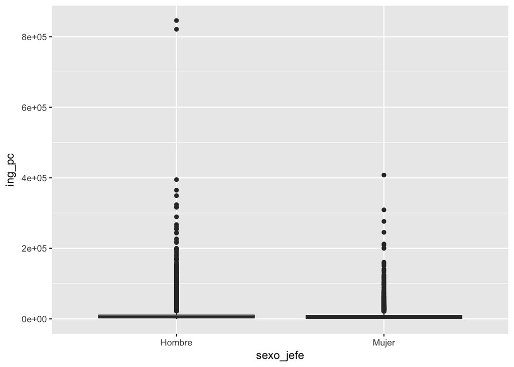

```r
qq<-qplot(sexo_jefe, ing_pc, data = enigh_concentrado, geom = "boxplot")
qq #imprimo mi objeto
```

Si cambiamos la escala a logarítmica, podemos observar mejor

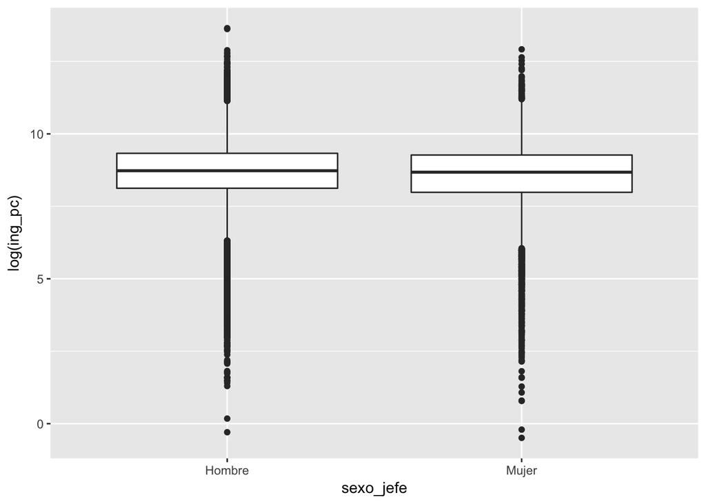

```r
qplot(sexo_jefe, log(ing_pc), data = enigh_concentrado, geom = "boxplot")
```

Podemos también ver estas diferencias por sexo, con una tercera variable, que serán nuestros “facets”"

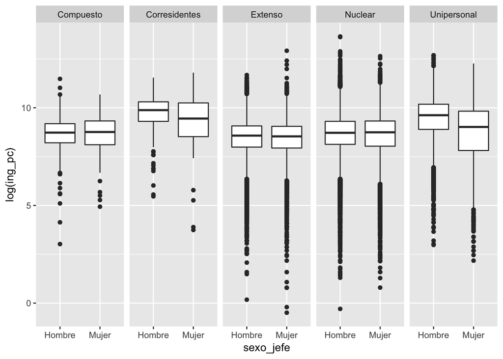

```r
qplot(sexo_jefe, log(ing_pc), data = enigh_concentrado, geom = "boxplot") + facet_grid(. ~clase_hog)
```

Si no queremos usar el grid (que da control de qué va en horizontal y en lo vertical), podemos usar facet_wrap

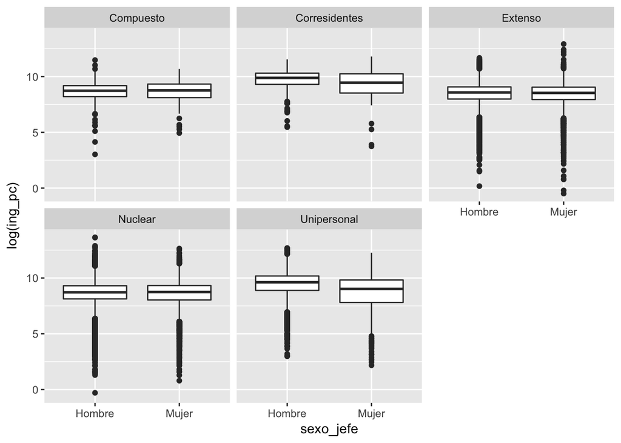

```r
qplot(sexo_jefe, log(ing_pc), data = enigh_concentrado, geom = "boxplot") + facet_wrap(~clase_hog)
```

# Prueba chi-cuadrado chi-sq

```r
table(enigh_concentrado$clase_hog, enigh_concentrado$sexo_jefe)
```

```
##
##                 Hombre Mujer
##   Compuesto        331   188
##   Corresidentes    157    92
##   Extenso        10526  5880
##   Nuclear        36562  8813
##   Unipersonal     4342  3420
```

```r
chisq.test(enigh_concentrado$clase_hog, enigh_concentrado$sexo_jefe)
```

```
##
##  Pearson's Chi-squared test
##
## data:  enigh_concentrado$clase_hog and enigh_concentrado$sexo_jefe
## X-squared = 3192.1, df = 4, p-value < 2.2e-16
```